# PSTAT 131 HW 6

Ezra Aguimatang

2022-12-16

## Tree-Based Models

For this assignment, we will continue working with the file `"pokemon.csv"`, found in `/131_HW_6_Data`. The file is from Kaggle: https://www.kaggle.com/abcsds/pokemon.

The [Pokémon](https://www.pokemon.com/us/) franchise encompasses video games, TV shows, movies, books, and a card game. This data set was drawn from the video game series and contains statistics about 721 Pokémon, or “pocket monsters.” In Pokémon games, the user plays as a trainer who collects, trades, and battles Pokémon to (a) collect all the Pokémon and (b) become the champion Pokémon trainer.

Each Pokémon has a [primary type](https://bulbapedia.bulbagarden.net/wiki/Type) (some even have secondary types). Based on their type, a Pokémon is strong against some types, and vulnerable to others. (Think rock, paper, scissors.) A Fire-type Pokémon, for example, is vulnerable to Water-type Pokémon, but strong against Grass-type.

The goal of this assignment is to build a statistical learning model that can predict the **primary type** of a Pokémon based on its generation, legendary status, and six battle statistics.

**Note: Fitting ensemble tree-based models can take a little while to run. Consider running your models outside of the .Rmd, storing the results, and loading them in your .Rmd to minimize time to knit.**

### Exercise 1

Read in the data and set things up as in Homework 5:

- Use `clean_names()`
- Filter out the rarer Pokémon types
- Convert `type_1` and `legendary` to factors

Do an initial split of the data; you can choose the percentage for splitting. Stratify on the outcome variable.

Fold the training set using *v*-fold cross-validation, with `v = 5`. Stratify on the outcome variable.

Set up a recipe to predict `type_1` with `legendary`, `generation`, `sp_atk`, `attack`, `speed`, `defense`, `hp`, and `sp_def`:

- Dummy-code `legendary` and `generation`;
- Center and scale all predictors.

## Solution 1:

```r
Pokemon_data <- read.csv(file="131_HW_6_Data/Pokemon.csv")
Pokemon_data <- Pokemon_data %>%
  clean_names()
Pokemon_data <- Pokemon_data %>%
  filter(grepl("Bug|Fire|Grass|Normal|Water|Psychic", type_1))
Pokemon_data$type_1 <- factor(Pokemon_data$type_1)
Pokemon_data$legendary <- factor(Pokemon_data$legendary)
Pokemon_data$generation <- factor(Pokemon_data$generation)

set.seed(8488)

Pokemon_split <- initial_split(Pokemon_data, prop=0.70, strata=type_1)
Pokemon_train <- training(Pokemon_split)
Pokemon_test <- testing(Pokemon_split)

Pokemon_folds <- vfold_cv(Pokemon_train, v = 5, strata=type_1)

Pokemon_recipe <- recipe(type_1 ~ legendary + generation + sp_atk + attack +
                           speed + defense + hp + sp_def, data=Pokemon_train) %>%
  step_dummy(c(legendary, generation)) %>%
  step_normalize(all_predictors())

Pokemon_recipe %>%
  prep() %>%
  juice()
```

```
## # A tibble: 318 × 13
##    sp_atk attack   speed defense      hp   sp_def type_1 legen…¹ gener…² gener…³
##     <dbl>  <dbl>   <dbl>   <dbl>   <dbl>    <dbl> <fct>    <dbl>   <dbl>   <dbl>
##  1 -1.62  -1.36  -0.820   -1.18  -0.850  -1.82    Bug     -0.245  -0.416  -0.486
##  2  0.522 -0.886  0.0241  -0.649 -0.310   0.365   Bug     -0.245  -0.416  -0.486
##  3 -1.62  -1.20  -0.652   -1.35  -1.03   -1.82    Bug     -0.245  -0.416  -0.486
##  4 -1.47  -1.51  -1.16    -0.649 -0.850  -1.63    Bug     -0.245  -0.416  -0.486
##  5 -0.857  0.525  0.193   -1.00  -0.130   0.365   Bug     -0.245  -0.416  -0.486
##  6 -1.78   2.40   2.56    -1.00  -0.130   0.365   Bug     -0.245  -0.416  -0.486
##  7 -0.857 -0.102 -1.50    -0.472 -1.21   -0.544   Bug     -0.245  -0.416  -0.486
##  8  0.522 -0.259  0.700   -0.296  0.0505  0.183   Bug     -0.245  -0.416  -0.486
##  9 -0.550  1.15   1.21     0.410  0.0505  0.365   Bug     -0.245  -0.416  -0.486
## 10 -0.550  1.62   0.531    1.12  -0.130   0.00126 Bug     -0.245  -0.416  -0.486
## # … with 308 more rows, 3 more variables: generation_X4 <dbl>,
## #   generation_X5 <dbl>, generation_X6 <dbl>, and abbreviated variable names
## #   ¹legendary_True, ²generation_X2, ³generation_X3
```

### Exercise 2

Create a correlation matrix of the training set, using the `corrplot` package. *Note: You can choose how to handle the continuous variables for this plot; justify your decision(s).*

What relationships, if any, do you notice? Do these relationships make sense to you?

## Solution 2:

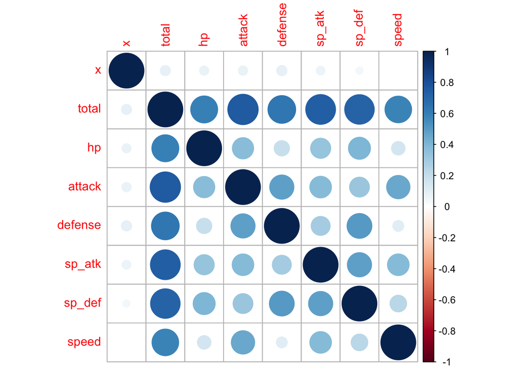

```r
Pokemon_train %>%
  dplyr::select(where(is.numeric)) %>%
  cor() %>%
  corrplot()
```

### Exercise 3

First, set up a decision tree model and workflow. Tune the `cost_complexity` hyperparameter. Use the same levels we used in Lab 7 – that is, `range = c(-3, -1)`. Specify that the metric we want to optimize is `roc_auc`.

Print an `autoplot()` of the results. What do you observe? Does a single decision tree perform better with a smaller or larger complexity penalty?

## Solution 3:

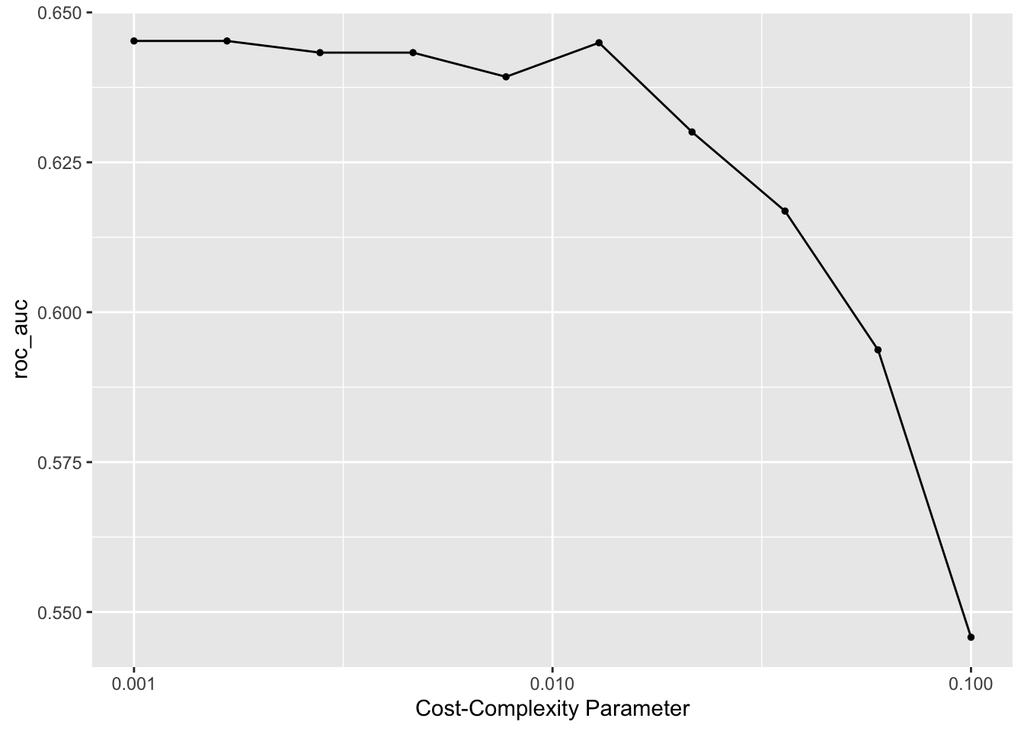

```r
tree_spec <- decision_tree() %>%
  set_engine("rpart")

class_tree_spec <- tree_spec %>%
  set_mode("classification")

class_tree_wf <- workflow() %>%
  add_model(class_tree_spec %>% set_args(cost_complexity = tune())) %>%
  add_formula(type_1 ~ legendary + generation + sp_atk + attack +
                speed + defense + hp + sp_def)

param_grid <- grid_regular(cost_complexity(range = c(-3, -1)), levels = 10)

tune_res <- tune_grid(
  class_tree_wf,
  resamples = Pokemon_folds,
  grid = param_grid,
  metrics = metric_set(yardstick::roc_auc)
)

autoplot(tune_res)
```

Time for this code chunk to run: 21.5783429145813

Looking at our plot above, the ROC AUC curve of this single decision tree has a mostly constant shape when `cost_complexity` is approximately in the the range `(0.001, 0.010)`. However, we see a quick decline in the the range `(0.010, 0.100)`. Based on this notion, we could conclude that a single decision tree performs better with a smaller complexity penalty and vice versa.

### Exercise 4

What is the `roc_auc` of your best-performing pruned decision tree on the folds? *Hint: Use `collect_metrics()` and `arrange()`.*

## Solution 4:

```r
best_pruned_tree <- arrange(collect_metrics(tune_res), desc(mean))
best_pruned_tree
```

```
## # A tibble: 10 × 7
##    cost_complexity .metric .estimator  mean     n std_err .config
##              <dbl> <chr>   <chr>      <dbl> <int>   <dbl> <chr>
##  1         0.001   roc_auc hand_till  0.645     5  0.0239 Preprocessor1_Model01
##  2         0.00167 roc_auc hand_till  0.645     5  0.0239 Preprocessor1_Model02
##  3         0.0129  roc_auc hand_till  0.645     5  0.0194 Preprocessor1_Model06
##  4         0.00278 roc_auc hand_till  0.643     5  0.0229 Preprocessor1_Model03
##  5         0.00464 roc_auc hand_till  0.643     5  0.0229 Preprocessor1_Model04
##  6         0.00774 roc_auc hand_till  0.639     5  0.0254 Preprocessor1_Model05
##  7         0.0215  roc_auc hand_till  0.630     5  0.0247 Preprocessor1_Model07
##  8         0.0359  roc_auc hand_till  0.617     5  0.0119 Preprocessor1_Model08
##  9         0.0599  roc_auc hand_till  0.594     5  0.0141 Preprocessor1_Model09
## 10         0.1     roc_auc hand_till  0.546     5  0.0203 Preprocessor1_Model10
```

Time for this code chunk to run: 0.11838698387146

It appears that $0.6452386$ is the `roc_auc` of our best-performing pruned decision tree on the folds.

### Exercise 5

Using `rpart.plot`, fit and visualize your best-performing pruned decision tree with the *training* set.

## Solution 5:

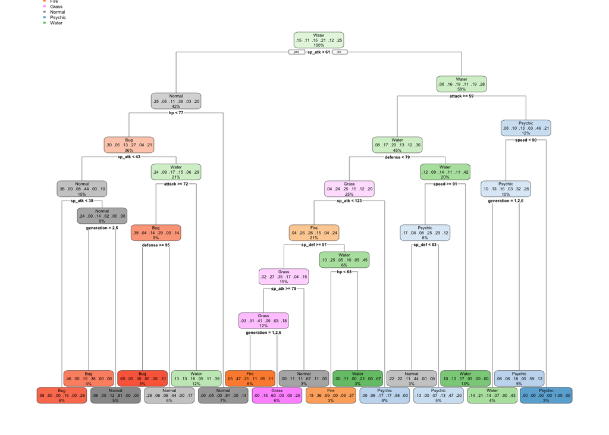

```r
best_complexity <- select_best(tune_res)

class_tree_final <- finalize_workflow(class_tree_wf, best_complexity)

class_tree_final_fit <- fit(class_tree_final, data = Pokemon_train)

class_tree_final_fit %>%
  extract_fit_engine() %>%
  rpart.plot(roundint=FALSE)
```

Time for this code chunk to run: 6.98833513259888

### Exercise 5

Now set up a random forest model and workflow. Use the `ranger` engine and set `importance = "impurity"`. Tune `mtry`, `trees`, and `min_n`. Using the documentation for `rand_forest()`, explain in your own words what each of these hyperparameters represent.

Create a regular grid with 8 levels each. You can choose plausible ranges for each hyperparameter. Note that `mtry` should not be smaller than 1 or larger than 8. **Explain why not. What type of model would `mtry = 8` represent?**

## Solution 5:

```r
rf_spec <- rand_forest(mtry = tune(), trees = tune(), min_n = tune()) %>%
  set_engine("ranger", importance = "impurity") %>%
  set_mode("classification")

rand_tree_wf <- workflow() %>%
  add_model(rf_spec) %>%
  add_formula(type_1 ~ legendary + generation + sp_atk + attack +
                speed + defense + hp + sp_def)

forest_param_grid <- grid_regular(mtry(range = c(2, 7)), trees(range = c(1, 6)),
                                  min_n(range = c(3,5)), levels = 8)
```

Time for this code chunk to run: 0.375174045562744

For the `rf_spec` model, we are tuning 3 hyperparameters: `mtry`, `trees`, and `min_n`. The hyperparameter, `mtry`, is the number of predictors to be sampled while the model is built. The hyperparameter, `trees`, is the number of trees in the model, and finally, `min_n` is a hyperparameter indicating the set minimum number of samples for each tree node before it can be split into a subtree.

### Exercise 6

Specify `roc_auc` as a metric. Tune the model and print an `autoplot()` of the results. What do you observe? What values of the hyperparameters seem to yield the best performance?

## Solution 6:

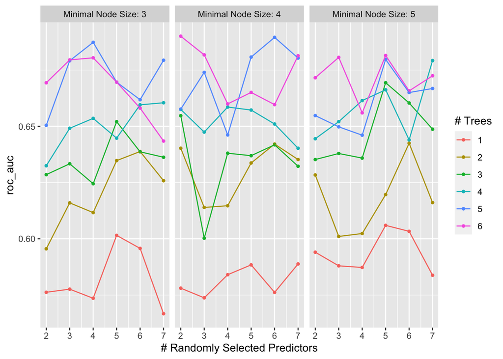

```r
forest_tune_res <- tune_grid(
  rand_tree_wf,
  resamples = Pokemon_folds,
  grid = forest_param_grid,
  metrics = metric_set(yardstick::roc_auc)
)

autoplot(forest_tune_res)
```

Time for this code chunk to run: 4.24263410170873

### Exercise 7

What is the `roc_auc` of your best-performing random forest model on the folds? *Hint: Use `collect_metrics()` and `arrange()`.*

## Solution 7:

```r
best_rd_tree <- arrange(collect_metrics(forest_tune_res), desc(mean))
head(best_rd_tree)
```

```
## # A tibble: 6 × 9
##    mtry trees min_n .metric .estimator  mean     n std_err .config
##   <int> <int> <int> <chr>   <chr>      <dbl> <int>   <dbl> <chr>
## 1     2     6     4 roc_auc hand_till  0.690     5 0.0152  Preprocessor1_Model0…
## 2     6     5     4 roc_auc hand_till  0.690     5 0.0119  Preprocessor1_Model0…
## 3     4     5     3 roc_auc hand_till  0.687     5 0.0152  Preprocessor1_Model0…
## 4     3     6     4 roc_auc hand_till  0.682     5 0.0110  Preprocessor1_Model0…
## 5     5     6     5 roc_auc hand_till  0.681     5 0.00793 Preprocessor1_Model1…
## 6     7     6     4 roc_auc hand_till  0.681     5 0.0127  Preprocessor1_Model0…
```

Time for this code chunk to run: 0.132117986679077

It appears that $0.690$ is the `roc_auc` of our best-performing random forest model on the folds.

### Exercise 8

Create a variable importance plot, using `vip()`, with your best-performing random forest model fit on the *training* set.

Which variables were most useful? Which were least useful? Are these results what you expected, or not?

## Solution 8:

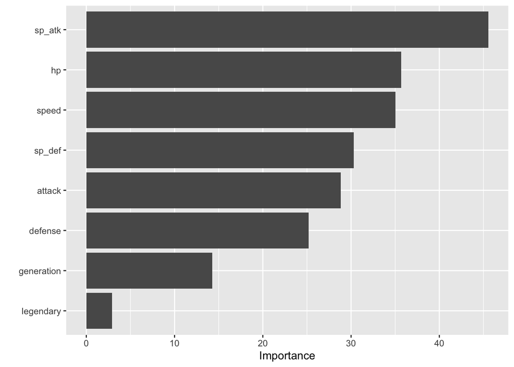

```r
best_forest_complexity <- select_best(forest_tune_res)

rand_tree_final <- finalize_workflow(rand_tree_wf, best_forest_complexity)

rand_tree_final_fit <- fit(rand_tree_final, data = Pokemon_train)

rand_tree_final_fit %>%
  extract_fit_parsnip() %>%
  vip()
```

Time for this code chunk to run: 2.35126900672913

1. 3 Most Useful Variables (most to least useful):
   - `sp_atk`
   - `hp`
   - `speed`
2. 3 Least Useful Variables (least to more useful):
   - `legendary`
   - `generation`
   - `defense`

### Exercise 9

Finally, set up a boosted tree model and workflow. Use the `xgboost` engine. Tune `trees`. Create a regular grid with 10 levels; let `trees` range from 10 to 2000. Specify `roc_auc` and again print an `autoplot()` of the results.

What do you observe?

What is the `roc_auc` of your best-performing boosted tree model on the folds? *Hint: Use `collect_metrics()` and `arrange()`.*

## Solution 9:

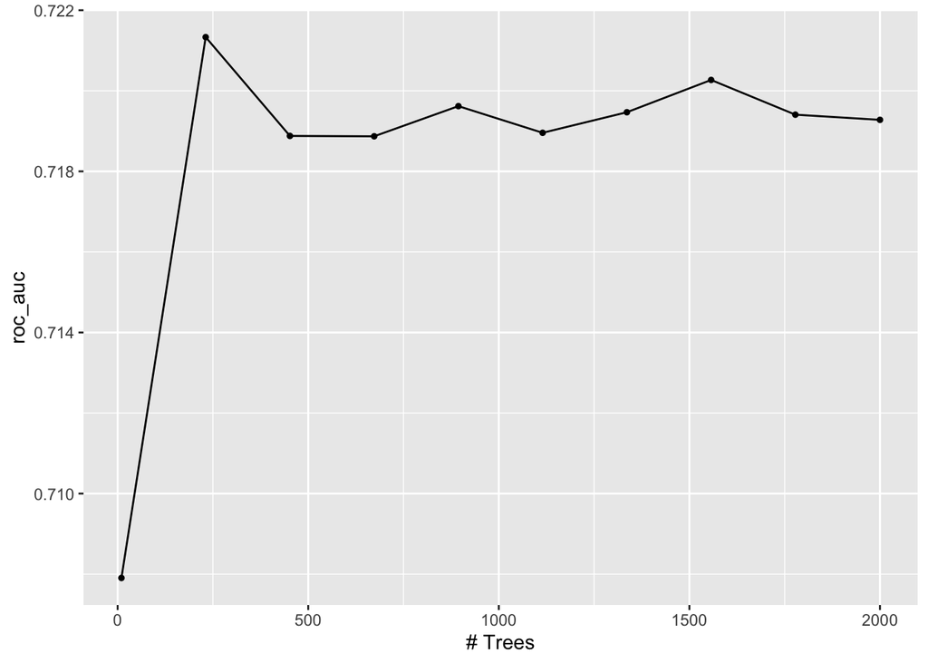

```r
boost_spec <- boost_tree(trees = tune()) %>%
  set_engine("xgboost") %>%
  set_mode("classification")

boost_tree_wf <- workflow() %>%
  add_model(boost_spec) %>%
  add_formula(type_1 ~ legendary + generation + sp_atk + attack +
                speed + defense + hp + sp_def)

boost_param_grid <- grid_regular(trees(range = c(10, 2000)), levels = 10)

boost_tune_res <- tune_grid(
  boost_tree_wf,
  resamples = Pokemon_folds,
  grid = boost_param_grid,
  metrics = metric_set(yardstick::roc_auc)
)

autoplot(boost_tune_res)
```

```r
best_boost_tree <- arrange(collect_metrics(boost_tune_res), desc(mean))
head(best_boost_tree)
```

```
## # A tibble: 6 × 7
##   trees .metric .estimator  mean     n std_err .config
##   <int> <chr>   <chr>      <dbl> <int>   <dbl> <chr>
## 1   231 roc_auc hand_till  0.721     5 0.0119  Preprocessor1_Model02
## 2  1557 roc_auc hand_till  0.720     5 0.00797 Preprocessor1_Model08
## 3   894 roc_auc hand_till  0.720     5 0.00927 Preprocessor1_Model05
## 4  1336 roc_auc hand_till  0.719     5 0.00810 Preprocessor1_Model07
## 5  1778 roc_auc hand_till  0.719     5 0.00781 Preprocessor1_Model09
## 6  2000 roc_auc hand_till  0.719     5 0.00758 Preprocessor1_Model10
```

Time for this code chunk to run: 31.7648310661316

### Exercise 10

Display a table of the three ROC AUC values for your best-performing pruned tree, random forest, and boosted tree models. Which performed best on the folds? Select the best of the three and use `select_best()`, `finalize_workflow()`, and `fit()` to fit it to the *testing* set.

Print the AUC value of your best-performing model on the testing set. Print the ROC curves. Finally, create and visualize a confusion matrix heat map.

Which classes was your model most accurate at predicting? Which was it worst at?

## Solution 10:

```r
best_roc_auc_trees <- c(best_pruned_tree$mean[1],
                        best_rd_tree$mean[1],
                        best_boost_tree$mean[1])

best_roc_auc_names <- c("Pruned Tree", "Random Forest", "Boosted Tree")

best_roc_auc <- tibble(Model = best_roc_auc_names,
                       ROC_AUC = best_roc_auc_trees)

best_roc_auc <- best_roc_auc %>%
  arrange(-best_roc_auc_trees)

best_roc_auc
```

```
## # A tibble: 3 × 2
##   Model         ROC_AUC
##   <chr>           <dbl>
## 1 Boosted Tree    0.721
## 2 Random Forest   0.690
## 3 Pruned Tree     0.645
```

```r
best_boost_complexity <- select_best(boost_tune_res)

boost_tree_final <- finalize_workflow(boost_tree_wf, best_boost_complexity)

boost_tree_final_fit <- fit(boost_tree_final, data = Pokemon_train)

roc <- augment(boost_tree_final_fit, new_data = Pokemon_test, type = 'prob')

roc %>%
  roc_auc(type_1, c(.pred_Bug, .pred_Fire, .pred_Grass, .pred_Normal,
                                       .pred_Water, .pred_Psychic))
```

```
## # A tibble: 1 × 3
##   .metric .estimator .estimate
##   <chr>   <chr>          <dbl>
## 1 roc_auc hand_till      0.644
```

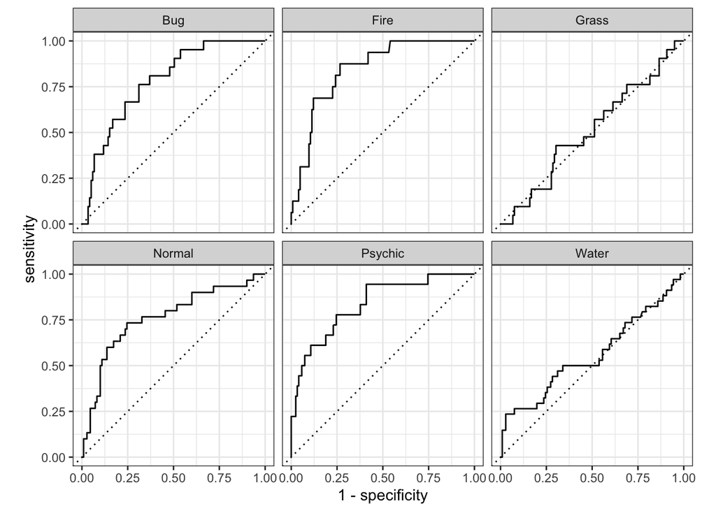

```r
roc %>%
  roc_curve(type_1, c(.pred_Bug, .pred_Fire, .pred_Grass, .pred_Normal,
                    .pred_Psychic, .pred_Water)) %>%
  autoplot()
```

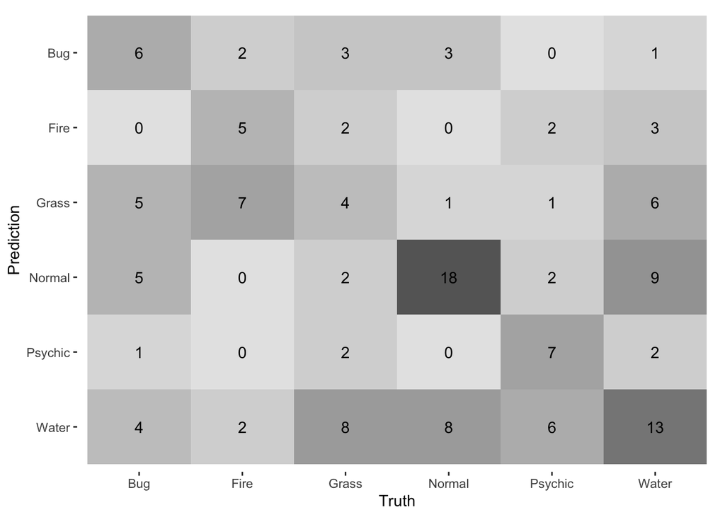

```r
roc %>%
  conf_mat(truth = type_1, estimate = .pred_class) %>%
  autoplot(type = "heatmap")
```

Time for this code chunk to run: 3.89386391639709

# NOT IN PSTAT 231

## For 231 Students

### Exercise 11

Using the `abalone.txt` data from previous assignments, fit and tune a random forest model to predict `age`. Use stratified cross-validation and select ranges for `mtry`, `min_n`, and `trees`. Present your results. What was the model’s RMSE on your testing set?